# MainStory

Marlin

10/28/2021

Overview

The two data set used in this analysis are the Madison case and waste water concentration data.

```
##         Date    Site Cases Tests   Per_pos Cases.Rolled Tests.Rolled
## 1 2020-08-15 Madison    29   836  3.468900     36.35714    1193.4286
## 2 2020-08-16 Madison    42   225 18.666667     35.00000    1134.4286
## 3 2020-08-17 Madison    14   641  2.184087     34.64286    1136.4286
## 4 2020-08-18 Madison    12  1165  1.030043     33.78571    1077.0714
## 5 2020-08-19 Madison    21  1341  1.565996     30.71429    1013.2143
## 6 2020-08-20 Madison    23   866  2.655889     29.78571     959.2857
##   Per_pos.Rolled
## 1       3.046445
## 2       3.085254
## 3       3.048397
## 4       3.136813
## 5       3.031371
## 6       3.104989
```

```
##         Date    Site    N1 N1Error
## 1 2020-09-15 Madison 63618    5938
## 2 2020-09-19 Madison 11442    1619
## 3 2020-09-22 Madison 39145    2835
## 4 2020-09-25 Madison 28553    2132
## 5 2020-09-24 Madison 16743    7255
## 6 2020-09-23 Madison 30509     278
```

A simple display of the data shows the core components of this story. First that both data sets are extremely noisy. And that there is a hint of a relationship between the two signals.

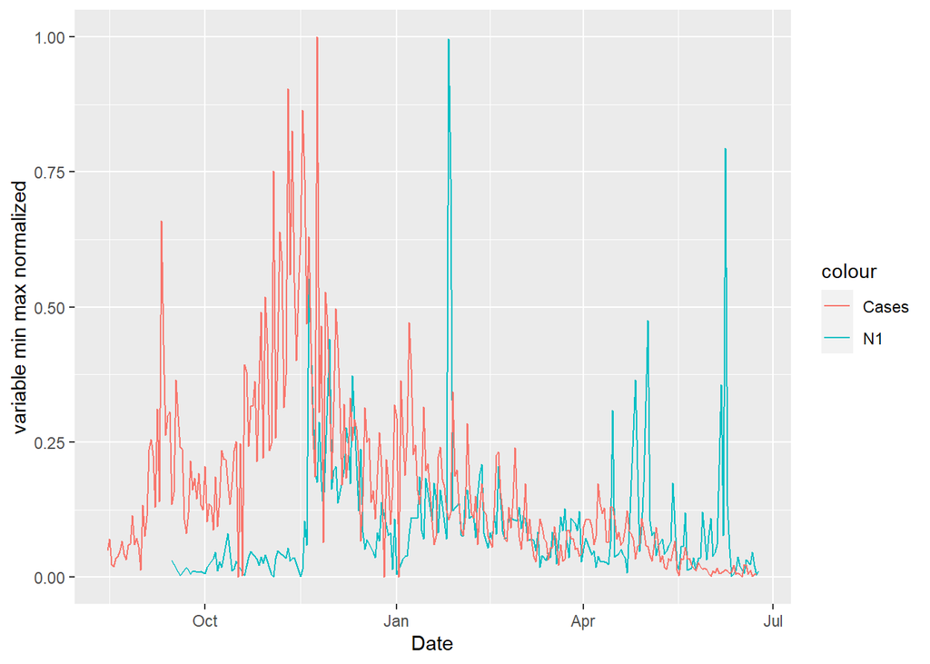

```r
ggplot()+
  geom_line(aes(x=Date,y=(N1-min(N1,na.rm=TRUE))/max(N1,na.rm=TRUE),color="N1"),data=LIMSFullDF)+
  geom_line(aes(x=Date,y=(Cases-min(Cases,na.rm=TRUE))/max(Cases,na.rm=TRUE),color="Cases"),data=FullLatCaseDFRoll)+
  labs(y="variable min max normalized")
```

A key component to this relationship is that the relationship between N1 and Case involves a gamma distribution modeling both the time between catching Covid-19 and getting a test and the concentration of the shedded particles. We found a gamma distribution with mean 11.73 days and a sd of 7.68 match’s other research and gives good results.

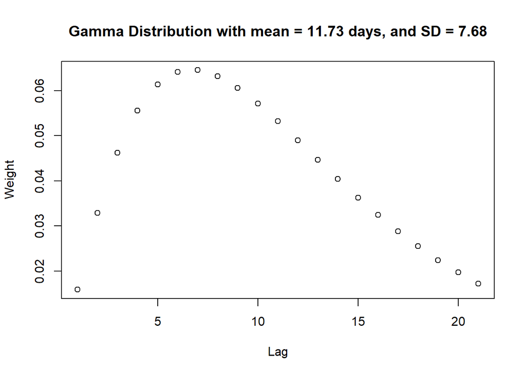

```r
scale =5.028338
shape =2.332779

weights <- dgamma(1:21,scale = scale,shape = shape)
plot(weights,
            main=paste("Gamma Distribution with mean = 11.73 days, and SD = 7.68"),
            ylab = "Weight",
            xlab = "Lag")
```

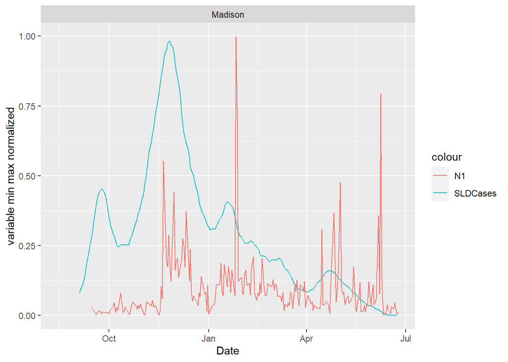

```r
SLDDF <- SLDSmoothing(FullLatCaseDFRoll,"Cases",Weights=weights)%>%
  filter(Site %in% c("Madison"))

ggplot()+
  geom_line(aes(x=Date,y=(SLDCases-min(SLDCases,na.rm=TRUE))/max(SLDCases,na.rm=TRUE),color="SLDCases"),data=SLDDF)+
  geom_line(aes(x=Date,y=(N1-min(N1,na.rm=TRUE))/max(N1,na.rm=TRUE),color="N1"),data=LIMSFullDF)+
  facet_wrap(~Site)+
  labs(y="variable min max normalized")
```

To aid this smoothing we have a first pass of removing obvious outliers and doing light smoothing of the N1 data.

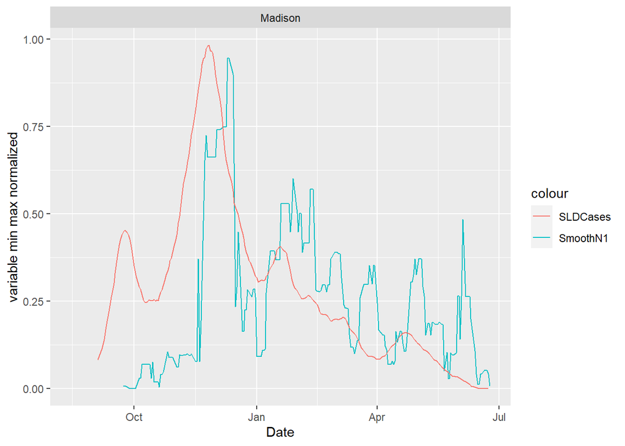

```r
DaySmoothed <- 4


RefinedLIMSFullDF <- LIMSFullDF%>%
  mutate(SmoothN1=c(rep(NA,DaySmoothed-1),rollmedian(N1,DaySmoothed)))

RefinedLIMSFullDF%>%
  ggplot()+
  geom_line(aes(x=Date,y=(SmoothN1-min(SmoothN1,na.rm=TRUE))/max(SmoothN1,na.rm=TRUE),color="SmoothN1"))+
  geom_line(aes(x=Date,y=(SLDCases-min(SLDCases,na.rm=TRUE))/max(SLDCases,na.rm=TRUE),color="SLDCases"),data=SLDDF)+
  facet_wrap(~Site)+
  labs(y="variable min max normalized")
```

To isolate this relationship we used a primitive binning relationship. This clarifies the relationship we see hints of in the previous graphic and masks the noise in the data.

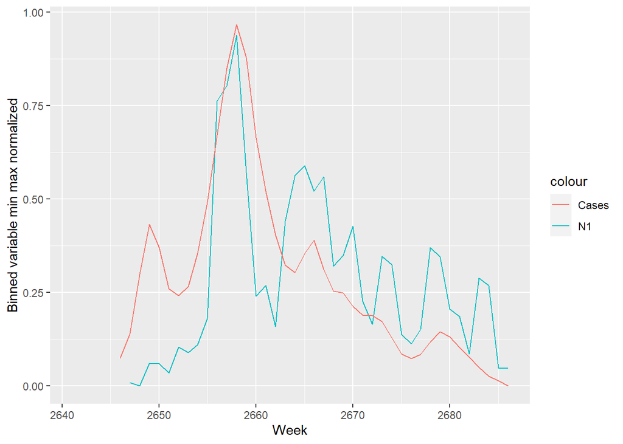

```r
medianMean <- function(Vec){
  return(mean(replace(Vec, c(which.min(Vec), which.max(Vec)), NA), na.rm = TRUE))
}

StartDate=4
DaySmoothing=7
Lag=14

BinDF <- full_join(SLDDF,RefinedLIMSFullDF,by=c("Date","Site"))%>%
  select(Date,SLDCases,SmoothN1)%>%
    mutate(MovedCases = data.table::shift(SLDCases,Lag),
           Week=(as.numeric(Date)+StartDate)%/%DaySmoothing)%>%
    group_by(Week)%>%
  #filter(SmoothN1<max(SmoothN1,na.rm=TRUE)/1.5)%>%
  #filter(Week>2650)%>%
  summarise(BinnedCases=mean(MovedCases,na.rm=TRUE),BinnedN1=mean(SmoothN1,na.rm=TRUE))



BinDF%>%
  ggplot()+
  geom_line(aes(x=Week,y=(BinnedN1-min(BinnedN1,na.rm=TRUE))/max(BinnedN1,na.rm=TRUE),color="N1"))+
  geom_line(aes(x=Week,y=(BinnedCases-min(BinnedCases,na.rm=TRUE))/max(BinnedCases,na.rm=TRUE),color="Cases"))+
  labs(y="Binned variable min max normalized")
```

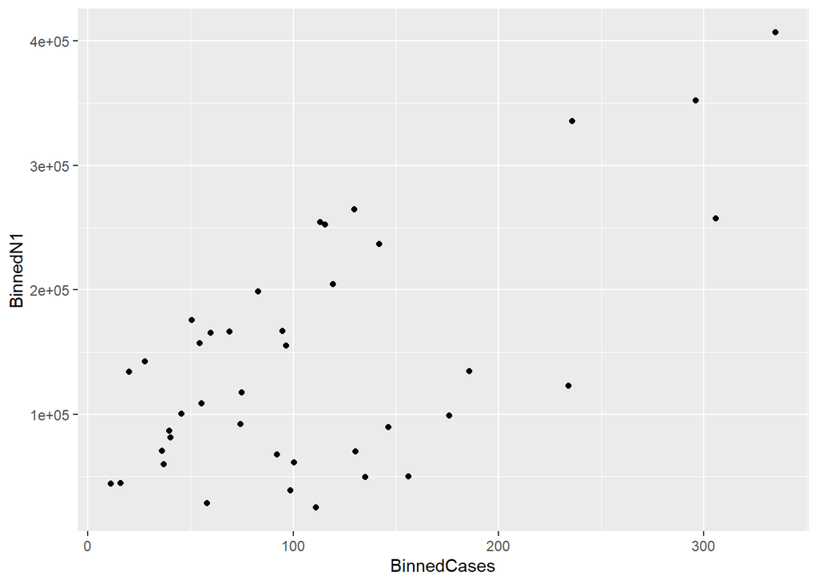

```r
BinDF%>%
  ggplot()+
  geom_point(aes(x=BinnedCases,y=BinnedN1))
```

```r
cor(BinDF$BinnedN1,BinDF$BinnedCases,use="pairwise.complete.obs")
```

```
## [1] 0.63007
```

```r
summary(lm(BinnedCases~BinnedN1,data=BinDF))
```

```
##
## Call:
## lm(formula = BinnedCases ~ BinnedN1, data = BinDF)
##
## Residuals:
##    Min     1Q Median     3Q    Max
## -85.93 -46.41 -23.26  59.96 134.06
##
## Coefficients:
##              Estimate Std. Error t value Pr(>|t|)
## (Intercept) 3.396e+01  1.818e+01   1.868   0.0695 .
## BinnedN1    5.369e-04  1.073e-04   5.002 1.32e-05 ***
## ---
## Signif. codes:  0 '***' 0.001 '**' 0.01 '*' 0.05 '.' 0.1 ' ' 1
##
## Residual standard error: 62.97 on 38 degrees of freedom
##   (6 observations deleted due to missingness)
## Multiple R-squared:  0.397,  Adjusted R-squared:  0.3811
## F-statistic: 25.02 on 1 and 38 DF,  p-value: 1.321e-05
```

To generate this relationship without reducing the amount of data we rely on a Loess smoothing of the data. The first step is to get a more rigorous measure of the relationship of the data. Here we will use cross correlation. These figures sup port the work done in previous steps.

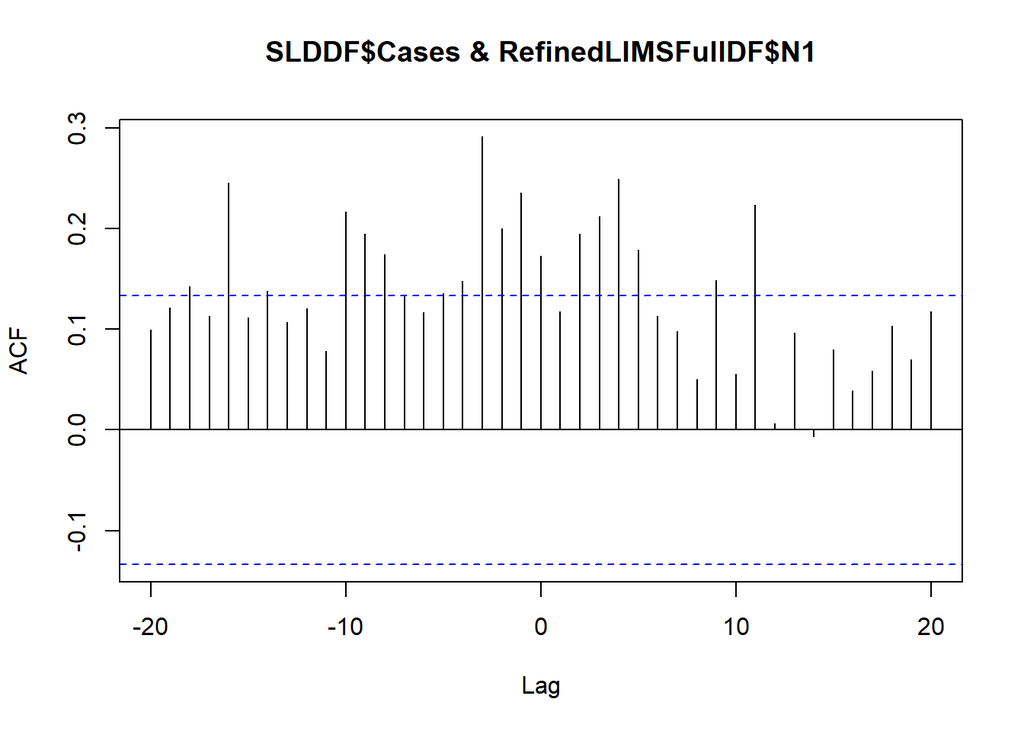

```r
ccf(SLDDF$Cases,RefinedLIMSFullDF$N1,na.action=na.pass)
```

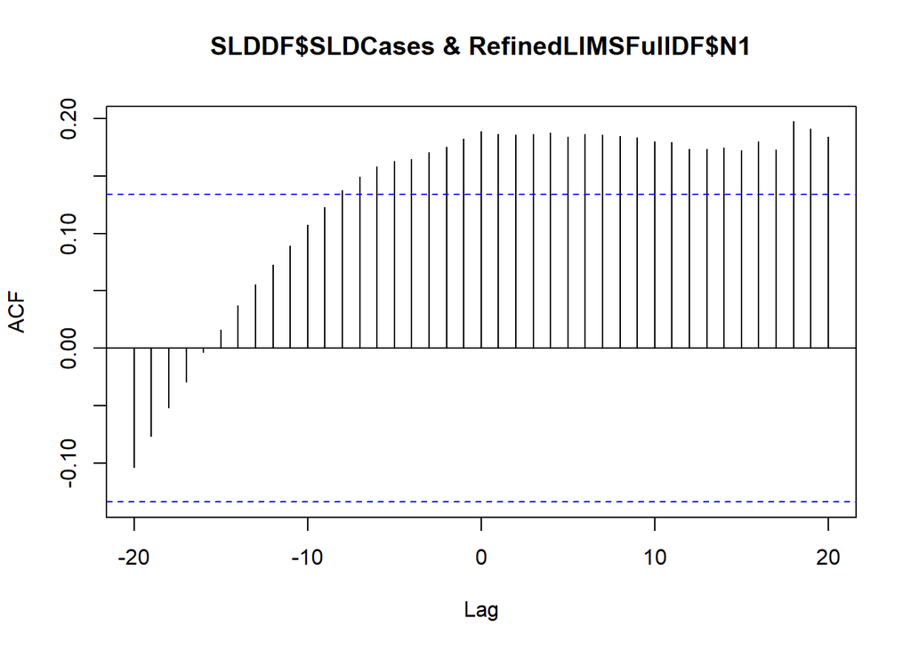

```r
#title(main ="Cases Vs. N1")

ccf(SLDDF$SLDCases,RefinedLIMSFullDF$N1,na.action=na.pass)
```

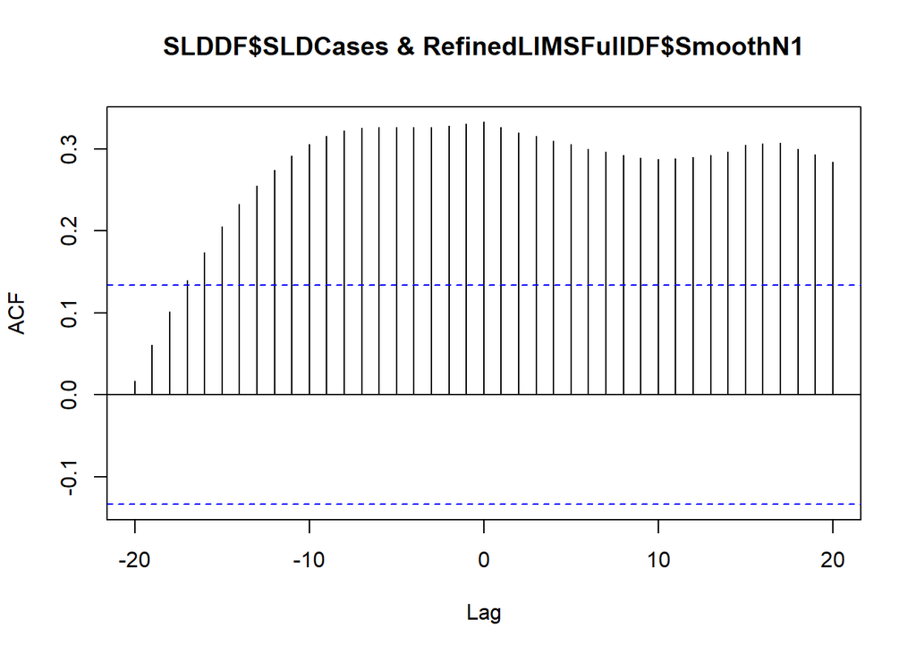

```r
#title(main="SLD Smoothed Cases Vs.N1")
ccf(SLDDF$SLDCases,RefinedLIMSFullDF$SmoothN1,na.action=na.pass)
```

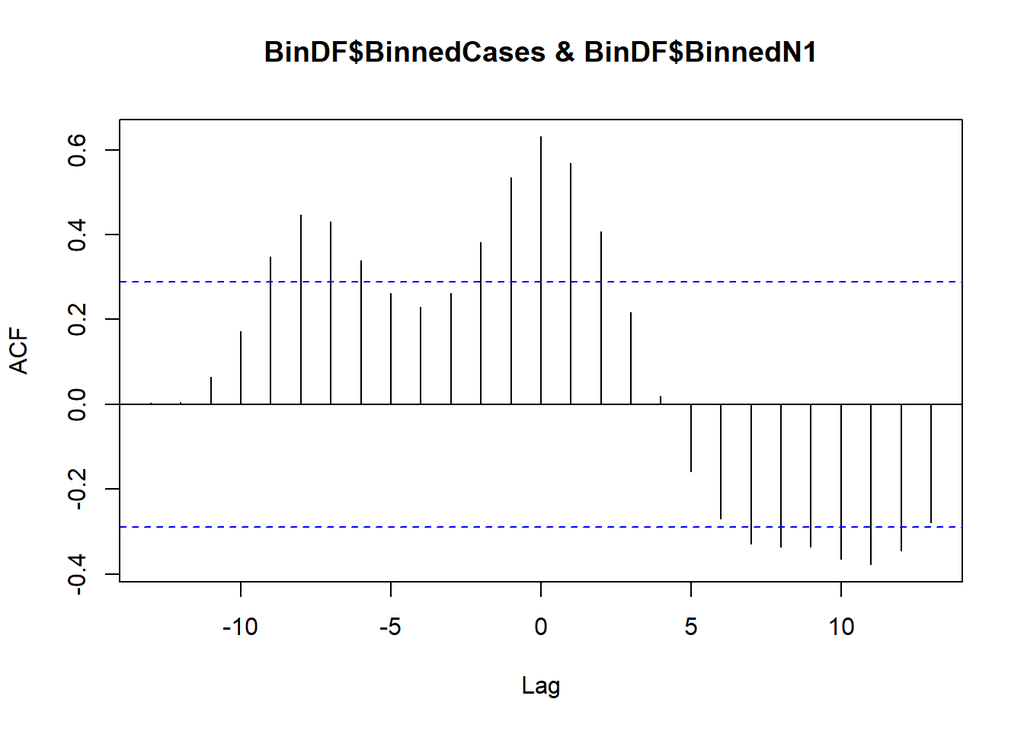

```r
#title(main="SLD Smoothed Cases Vs. Smoothed N1")
ccf(BinDF$BinnedCases,BinDF$BinnedN1,na.action=na.pass)
```

```r
#title(main="Binned Cases Vs. Binned N1")
```

The loess smoothing is a way of generating smooth curves from noisy data. The displayed plot shows the visual power of this smoothing. We see a relationship in the big patterns but also multiple sub paterns match. We see in general that smoothed N1 both lags and leads the case data.

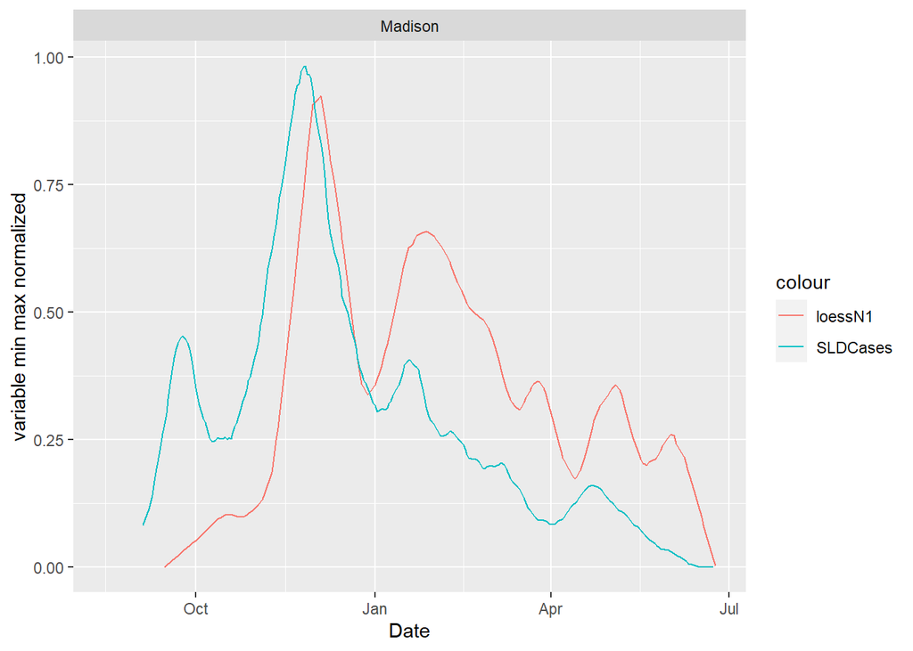

```r
RefinedLIMSFullDF$loessN1 <- loessFit(y=(RefinedLIMSFullDF$N1),
                      x=RefinedLIMSFullDF$Date,
                      span=.13,
                      iterations=3)$fitted


RefinedLIMSFullDF%>%
  ggplot()+
  geom_line(aes(x=Date,y=(loessN1-min(loessN1,na.rm=TRUE))/max(loessN1,na.rm=TRUE),color="loessN1"))+
  geom_line(aes(x=Date,y=(SLDCases-min(SLDCases,na.rm=TRUE))/max(SLDCases,na.rm=TRUE),color="SLDCases"),data=SLDDF)+
  facet_wrap(~Site)+
  labs(y="variable min max normalized")
```

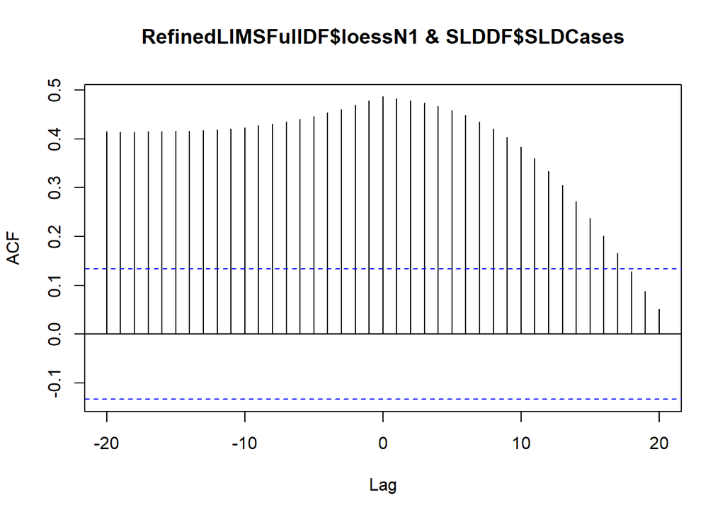

```r
ccf(RefinedLIMSFullDF$loessN1,SLDDF$SLDCases,na.action=na.pass)
```

Finally we wish to get a statistically powerful analysis we turn to formal time series tools like ARIMA models.

```r
FullDF <- full_join(RefinedLIMSFullDF,SLDDF,by=c("Date","Site"))%>%
  select(loessN1,SLDCases)


summary(arima(FullDF$SLDCases,xreg=FullDF$loessN1))
```

```
##
## Call:
## arima(x = FullDF$SLDCases, xreg = FullDF$loessN1)
##
## Coefficients:
##       intercept  FullDF$loessN1
##         16.0383           6e-04
## s.e.    10.2378           1e-04
##
## sigma^2 estimated as 4604:  log likelihood = -1206.16,  aic = 2418.31
##
## Training set error measures:
##                         ME     RMSE      MAE       MPE     MAPE   MASE
## Training set -1.299657e-13 67.85074 56.70953 -89.10748 120.6653 8.4499
##                   ACF1
## Training set 0.9918247
```

```r
#plot(resid(arima(FullDF$SLDCases, order =c(0,1,0) ,xreg=FullDF$loessN1)))
```

Here is extensive Cross validation to check the predictive quality of the models

needs some refactoring

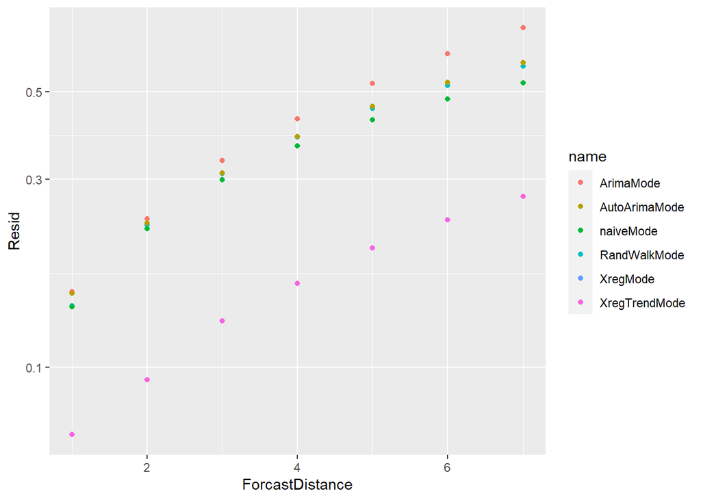

```r
library(forecast)
SLD_Data <- ts(log(FullDF$SLDCases), start = 2020, frequency = 365)
N1_Data_xreg <- ts(log(FullDF$loessN1), start = 2020, frequency = 365)
Trend_Data_xreg <- ts(log(FullDF$loessN1), start = 2020, frequency = 365)

far2_xreg <- function(x, h, xreg, newxreg) {
  forecast(Arima(x, order=c(1,1,0), xreg=xreg), xreg=newxreg)
}
far <- function(x, h){forecast(Arima(x, order=c(0,2,0)), h=h)}
far2 <- function(x, h){forecast(auto.arima(x), h=h)}
HAcVecGen <- function(TargetVec,
                      MaxForcast=70,ForcastMethod,...){

  ForcastResid <- tsCV(SLD_Data, ForcastMethod,
                       h=MaxForcast,...)
  PerAVec <- vector()
  for(i in 1:MaxForcast){
    Hvec=ForcastResid[-((282-i):281),i]
    SLDData <- TargetVec[-(1:i)]
    PerAVec[i] <- accuracy(ts(SLDData - Hvec),
                   ts(SLDData))[,2]
  }
  return(list(PerAVec,ForcastResid))
}

CustomLag <- function(x){
  x2 <- strsplit(x, "[ ]")
  LagN <- as.numeric(x2[[1]][1])
  Vec1 <- unlist(x2)[!(as.numeric(unlist(x2))%%1==0)]
  Vec2 <- c(rep(NA,LagN),Vec1[1:(length(Vec1)-LagN)])
  return(Vec2)
}

ForcastLength <- 7

XregMode <- HAcVecGen(SLD_Data,
                 ForcastMethod=far2_xreg,
                 MaxForcast=ForcastLength,
                 xreg=N1_Data_xreg)

XregTrendMode <- HAcVecGen(SLD_Data,
                 ForcastMethod=far2_xreg,
                 MaxForcast=ForcastLength,
                 xreg=Trend_Data_xreg)

ArimaMode <- HAcVecGen(SLD_Data,
                 ForcastMethod=far,
                 MaxForcast=ForcastLength)

AutoArimaMode <- HAcVecGen(SLD_Data,
                 ForcastMethod=far2,
                 MaxForcast=ForcastLength)

RandWalkMode <- HAcVecGen(SLD_Data,
                   ForcastMethod=rwf,
                   MaxForcast=ForcastLength,
                   drift=TRUE)

naiveMode <- HAcVecGen(SLD_Data,
                   ForcastMethod=naive,
                   MaxForcast=ForcastLength)

library(tidyr)


ErrorDF <- cbind("XregMode"=XregMode[[1]],
      "XregTrendMode"=XregTrendMode[[1]],
      "ArimaMode"=ArimaMode[[1]],
      "RandWalkMode"=RandWalkMode[[1]],
      "AutoArimaMode"=AutoArimaMode[[1]],
      "naiveMode"=naiveMode[[1]])%>%
  data.frame(ForcastDistance=1:ForcastLength)%>%
  pivot_longer(XregMode:naiveMode,values_to ="Resid")

ErrorDF%>%
  ggplot()+
  aes(x=ForcastDistance)+
  geom_point(aes(y=Resid,color=name))+
  scale_y_log10()
```

```r
DFNames <- paste0("h.",1:ForcastLength)
```

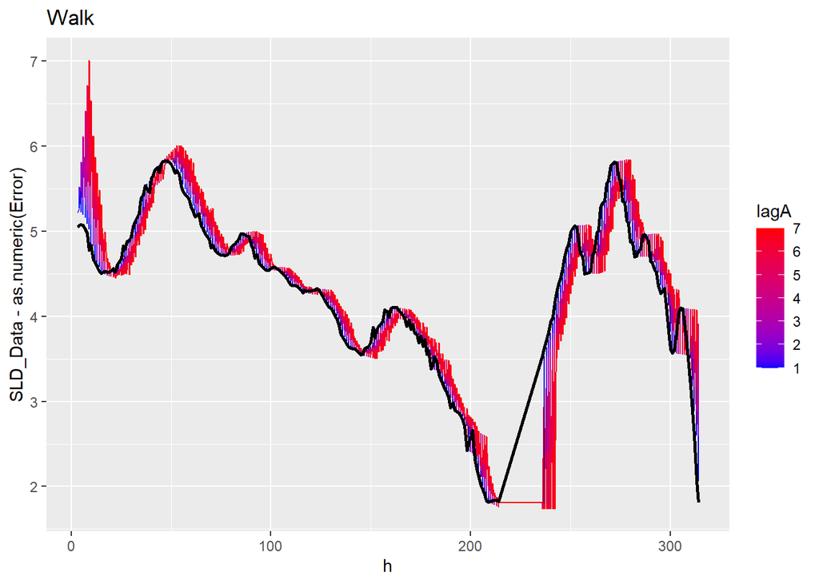

```r
ErrorPredictPlot <- function(X2){
  data.frame(X2[[2]],h=1:length(SLD_Data),SLD_Data)%>%
  pivot_longer(DFNames)%>%
  mutate(lagA= as.numeric(sub("h.", "" , name)))%>%
  group_by(lagA)%>%
  mutate(Error=paste(lagA,value))%>%
  mutate(Error=CustomLag(Error))%>%
  filter(!is.na(Error))
}
ErrorForcastPlot <- function(X2){
  data.frame(X2[[2]],h=1:length(SLD_Data),SLD_Data)%>%
  pivot_longer(DFNames)%>%
  mutate(lagA= as.numeric(sub("h.", "" , name)))%>%
  group_by(lagA)%>%
  mutate(Error=paste(lagA,value))%>%
  mutate(Error=CustomLag(Error))%>%
  filter(!is.na(Error))
}
WalkPredictResid <- suppressWarnings(ErrorForcastPlot(RandWalkMode))%>%
  ggplot()+
  aes(x=h)+
  geom_line(aes(y=SLD_Data-as.numeric(Error),color=lagA))+
    scale_color_gradient(low="blue", high="red")+
  geom_line(aes(y=SLD_Data),color="black",size=1)+
  ggtitle("Walk")

ArimaPredictResid <- suppressWarnings(ErrorForcastPlot(ArimaMode))%>%
  ggplot()+
  aes(x=h)+
  geom_line(aes(y=SLD_Data-as.numeric(Error),color=lagA))+
    scale_color_gradient(low="blue", high="red")+
  geom_line(aes(y=SLD_Data),color="black",size=1)+
  ggtitle("Arima")

XregPredictResid <- suppressWarnings(ErrorForcastPlot(XregMode))%>%
  ggplot()+
  aes(x=h)+
  geom_line(aes(y=SLD_Data-as.numeric(Error),color=lagA))+
    scale_color_gradient(low="blue", high="red")+
  geom_line(aes(y=SLD_Data),color="black",size=1)+
  ggtitle("Xreg")

XregTrendPredictResid <- suppressWarnings(ErrorForcastPlot(XregTrendMode))%>%
  ggplot()+
  aes(x=h)+
  geom_line(aes(y=SLD_Data-as.numeric(Error),color=lagA))+
    scale_color_gradient(low="blue", high="red")+
  geom_line(aes(y=SLD_Data),color="black",size=1)+
  ggtitle("XregTrend")

AutoArimaPredictResid <- suppressWarnings(ErrorForcastPlot(AutoArimaMode))%>%
  ggplot()+
  aes(x=h)+
  geom_line(aes(y=SLD_Data-as.numeric(Error),color=lagA))+
    scale_color_gradient(low="blue", high="red")+
  geom_line(aes(y=SLD_Data),color="black",size=1)+
  ggtitle("AutoArima")

WalkPredictResid
```

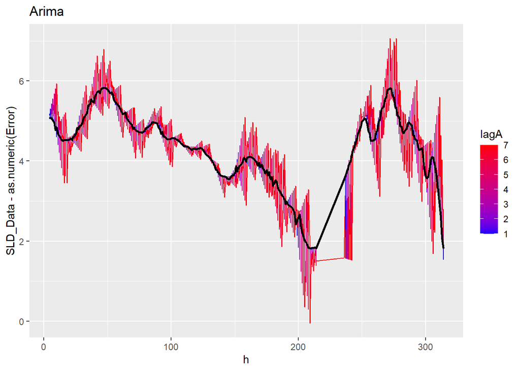

```r
ArimaPredictResid
```

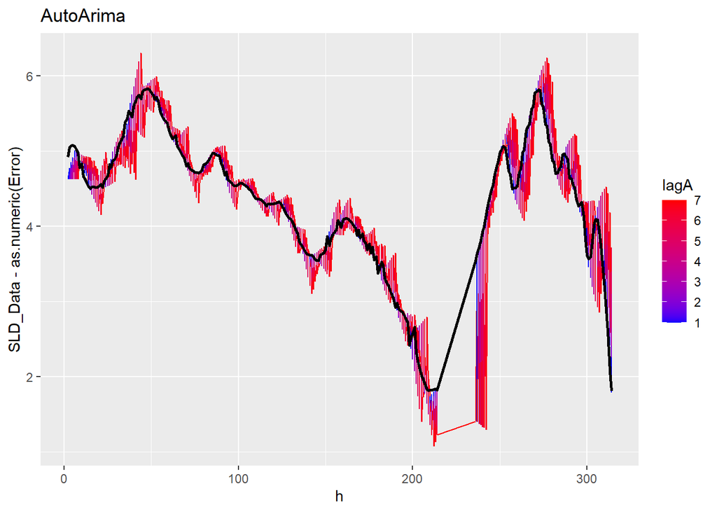

```r
AutoArimaPredictResid
```

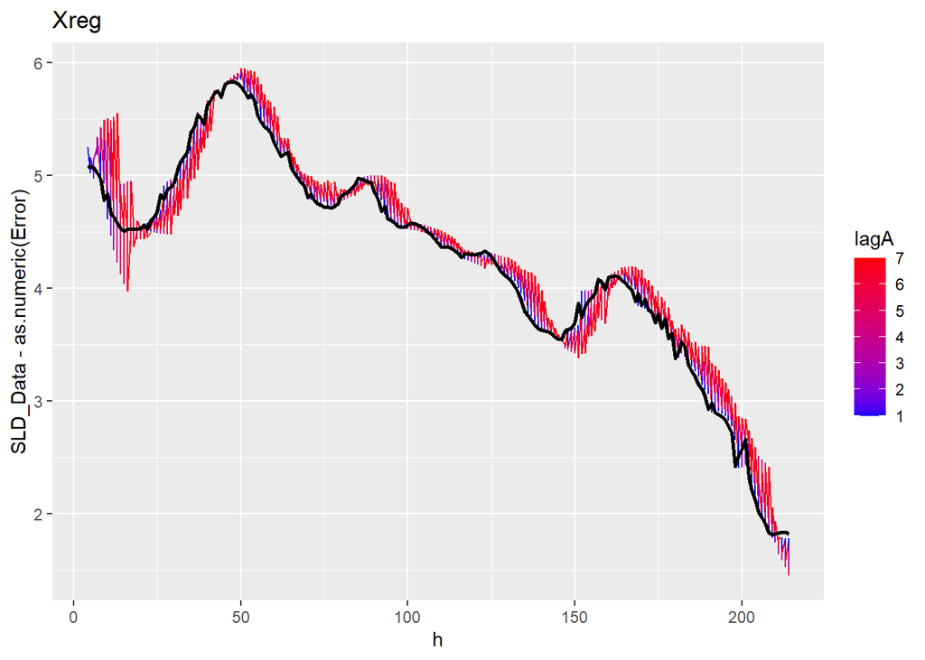

```r
XregPredictResid
```

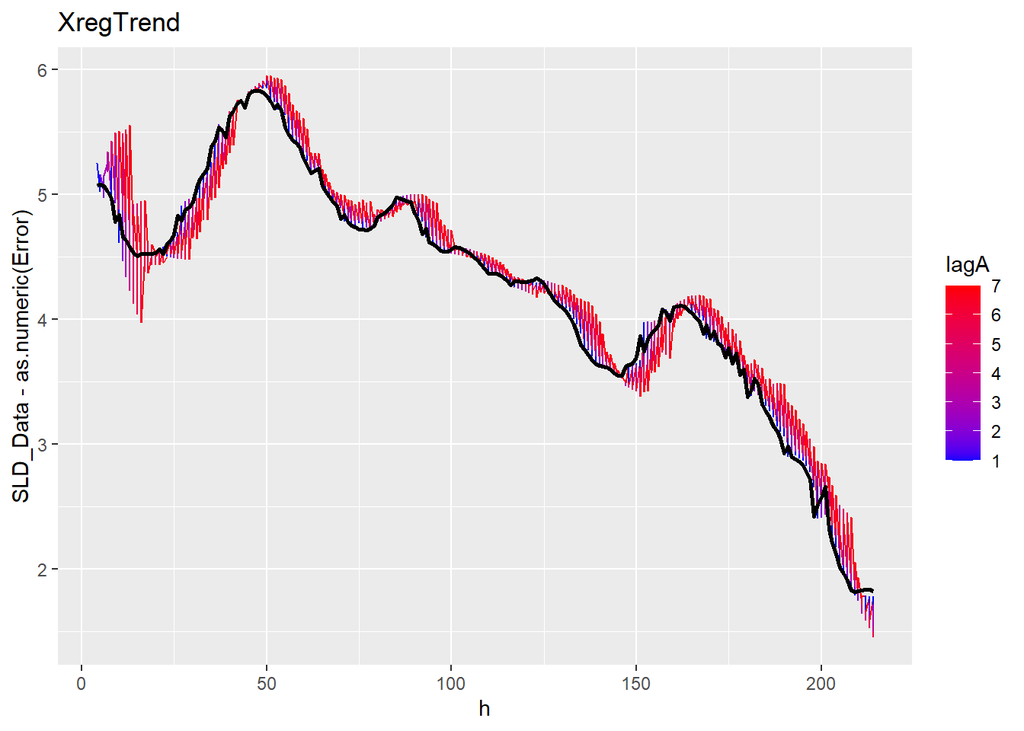

```r
XregTrendPredictResid
```